# STAT501_L78_RealEstate

Ada Lazuli

2025-10-26

```r
library(dplyr)
library(ggplot2)
library(qqplotr)
library(tidyr)
library(reactable)
library(openxlsx)
library(nortest) # For anderson-darling test
library(lmtest) # needed for Breusch-Pagan test
```

# Real Estate Analysis

## Data and Background

```r
df <- read.csv("~/Downloads/HW6RealEstate.csv")
head(df)
```

```
##   SalePrice SqrFeet Bedrooms Bathrooms Air AirSqrFeet AirBeds AirBath
## 1     360.0    3032        4         4   1       3032       4       4
## 2     340.0    2058        4         2   1       2058       4       2
## 3     250.0    1780        4         3   1       1780       4       3
## 4     205.5    1638        4         2   1       1638       4       2
## 5     275.5    2196        4         3   1       2196       4       3
## 6     248.0    1966        4         3   1       1966       4       3
```

The data has 521 observations, with the following fields:

1. **SalePrice** = the selling price of the home
2. **SqrFeet** = square foot area of the home
3. **Bedrooms** = number of bedrooms in the home
4. **Bathrooms** = number of bathrooms in the home
5. **Air** = 1 if the home has air conditioning, 0 if it does not
6. **AirSqrFeet** = interaction term calculated as Air*SqrFeet
7. **AirBeds** = interaction term calculated as Air*Bedrooms
8. **AirBath** = interaction term calculated as Air*Bathrooms

## Initial Analysis

```r
model <- lm(SalePrice ~ SqrFeet + Bedrooms + Bathrooms + Air + AirSqrFeet + AirBeds + AirBath, data = df)
summary(model)
```

```
##
## Call:
## lm(formula = SalePrice ~ SqrFeet + Bedrooms + Bathrooms + Air +
##     AirSqrFeet + AirBeds + AirBath, data = df)
##
## Residuals:
##     Min      1Q  Median      3Q     Max
## -202.94  -37.10   -5.82   23.83  357.80
##
## Coefficients:
##              Estimate Std. Error t value Pr(>|t|)
## (Intercept)  20.17780   32.50981   0.621  0.53509
## SqrFeet       0.07948    0.02217   3.585  0.00037 ***
## Bedrooms     -9.79684   10.61212  -0.923  0.35635
## Bathrooms    27.82334   12.26238   2.269  0.02368 *
## Air         -86.88601   35.76601  -2.429  0.01547 *
## AirSqrFeet    0.06370    0.02352   2.709  0.00698 **
## AirBeds      -2.88303   11.53331  -0.250  0.80271
## AirBath      -2.34430   13.46729  -0.174  0.86188
## ---
## Signif. codes:  0 '***' 0.001 '**' 0.01 '*' 0.05 '.' 0.1 ' ' 1
##
## Residual standard error: 75.2 on 513 degrees of freedom
## Multiple R-squared:  0.7054, Adjusted R-squared:  0.7014
## F-statistic: 175.5 on 7 and 513 DF,  p-value: < 2.2e-16
```

```r
anova(model)
```

```
## Analysis of Variance Table
##
## Response: SalePrice
##             Df  Sum Sq Mean Sq   F value    Pr(>F)
## SqrFeet      1 6666447 6666447 1178.8744 < 2.2e-16 ***
## Bedrooms     1   14478   14478    2.5603 0.1101910
## Bathrooms    1  166243  166243   29.3979  9.09e-08 ***
## Air          1   27206   27206    4.8110 0.0287274 *
## AirSqrFeet   1   71755   71755   12.6889 0.0004021 ***
## AirBeds      1     586     586    0.1036 0.7476490
## AirBath      1     171     171    0.0303 0.8618761
## Residuals  513 2900977    5655
## ---
## Signif. codes:  0 '***' 0.001 '**' 0.01 '*' 0.05 '.' 0.1 ' ' 1
```

Based on the anova,

The SSE for model is 2900977 with 513 degrees of freedom

$$MSE = \frac{SSE}{n - p} = \frac{2900977}{513} = 5654.93$$

Based on the the individual t-tests, it seems that the following might not be useful for predicting sale price: 1. Bedroom 2. AirBeds 3. AirBath

## A restricted model

```r
restricted <- lm(SalePrice ~ SqrFeet + Bathrooms + Air + AirSqrFeet, data = df)
summary(restricted)
```

```
##
## Call:
## lm(formula = SalePrice ~ SqrFeet + Bathrooms + Air + AirSqrFeet,
##     data = df)
##
## Residuals:
##     Min      1Q  Median      3Q     Max
## -211.39  -39.76   -4.51   22.14  368.51
##
## Coefficients:
##              Estimate Std. Error t value Pr(>|t|)
## (Intercept)   7.45620   29.63777   0.252 0.801468
## SqrFeet       0.07655    0.01670   4.583 5.75e-06 ***
## Bathrooms    22.09738    4.92031   4.491 8.75e-06 ***
## Air         -96.90708   32.32465  -2.998 0.002849 **
## AirSqrFeet    0.06098    0.01632   3.736 0.000208 ***
## ---
## Signif. codes:  0 '***' 0.001 '**' 0.01 '*' 0.05 '.' 0.1 ' ' 1
##
## Residual standard error: 75.62 on 516 degrees of freedom
## Multiple R-squared:  0.7004, Adjusted R-squared:  0.6981
## F-statistic: 301.6 on 4 and 516 DF,  p-value: < 2.2e-16
```

```r
anova(restricted)
```

```
## Analysis of Variance Table
##
## Response: SalePrice
##             Df  Sum Sq Mean Sq   F value    Pr(>F)
## SqrFeet      1 6666447 6666447 1165.8406 < 2.2e-16 ***
## Bathrooms    1  128267  128267   22.4316 2.818e-06 ***
## Air          1   22757   22757    3.9798 0.0465752 *
## AirSqrFeet   1   79829   79829   13.9606 0.0002075 ***
## Residuals  516 2950563    5718
## ---
## Signif. codes:  0 '***' 0.001 '**' 0.01 '*' 0.05 '.' 0.1 ' ' 1
```

## Testing The Interactions

$H_0: \forall_{i \in \{2,6,7\}} \beta_i = 0\\H_A: \exists_{i \in \{2,6,7\}} \beta_i \neq 0$

The p-value for this test is:

```r
1 - pf(0.898, 3, 513)
```

```
## [1] 0.4420033
```

## A third model

```r
third_model <- lm(SalePrice ~ SqrFeet + Bedrooms + Bathrooms + Air + AirSqrFeet, data = df)
df$resid <- resid(third_model)
df$fitted <- fitted(third_model)
summary(third_model)
```

```
##
## Call:
## lm(formula = SalePrice ~ SqrFeet + Bedrooms + Bathrooms + Air +
##     AirSqrFeet, data = df)
##
## Residuals:
##     Min      1Q  Median      3Q     Max
## -203.36  -38.64   -5.97   24.36  357.84
##
## Coefficients:
##              Estimate Std. Error t value Pr(>|t|)
## (Intercept)  21.72167   29.81645   0.729 0.466631
## SqrFeet       0.08441    0.01679   5.026 6.91e-07 ***
## Bedrooms    -12.20770    4.14686  -2.944 0.003388 **
## Bathrooms    25.94747    5.05623   5.132 4.07e-07 ***
## Air         -89.47486   32.18634  -2.780 0.005636 **
## AirSqrFeet    0.05793    0.01623   3.569 0.000392 ***
## ---
## Signif. codes:  0 '***' 0.001 '**' 0.01 '*' 0.05 '.' 0.1 ' ' 1
##
## Residual standard error: 75.06 on 515 degrees of freedom
## Multiple R-squared:  0.7053, Adjusted R-squared:  0.7025
## F-statistic: 246.6 on 5 and 515 DF,  p-value: < 2.2e-16
```

```r
anova(third_model)
```

```
## Analysis of Variance Table
##
## Response: SalePrice
##             Df  Sum Sq Mean Sq   F value    Pr(>F)
## SqrFeet      1 6666447 6666447 1183.1615 < 2.2e-16 ***
## Bedrooms     1   14478   14478    2.5696 0.1095453
## Bathrooms    1  166243  166243   29.5048 8.614e-08 ***
## Air          1   27206   27206    4.8284 0.0284384 *
## AirSqrFeet   1   71755   71755   12.7350 0.0003924 ***
## Residuals  515 2901734    5634
## ---
## Signif. codes:  0 '***' 0.001 '**' 0.01 '*' 0.05 '.' 0.1 ' ' 1
```

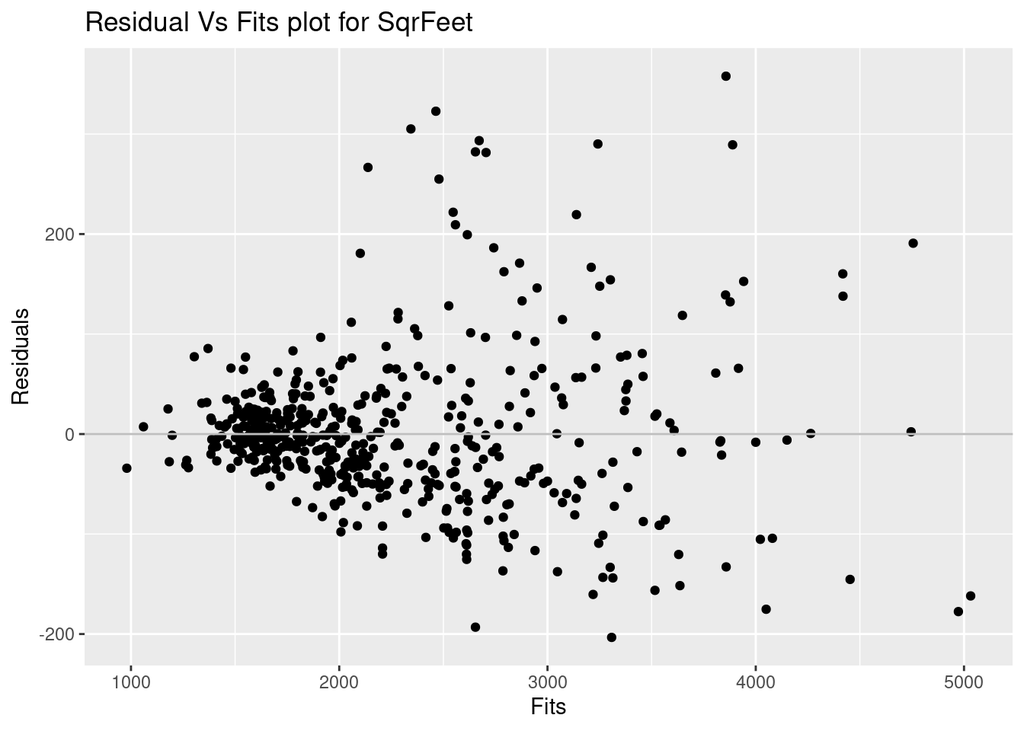

```r
ggplot(df, aes(x = SqrFeet, y=resid)) + geom_point() + ylab("Residuals") + xlab("Fits") + ggtitle("Residual Vs Fits plot for SqrFeet") +  geom_hline(yintercept = 0, color = "grey")
```

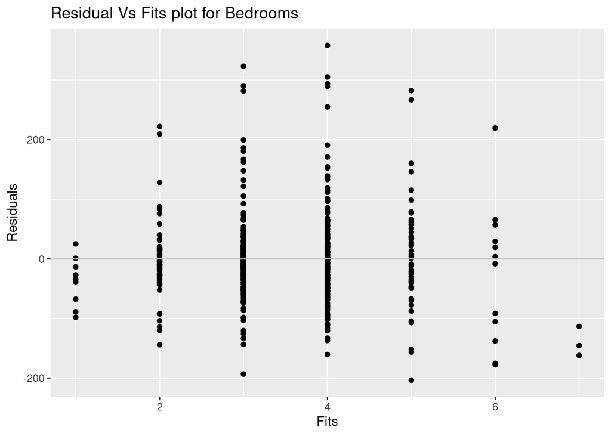

```r
ggplot(df, aes(x = Bedrooms, y=resid)) + geom_point() + ylab("Residuals") + xlab("Fits") + ggtitle("Residual Vs Fits plot for Bedrooms") +  geom_hline(yintercept = 0, color = "grey")
```

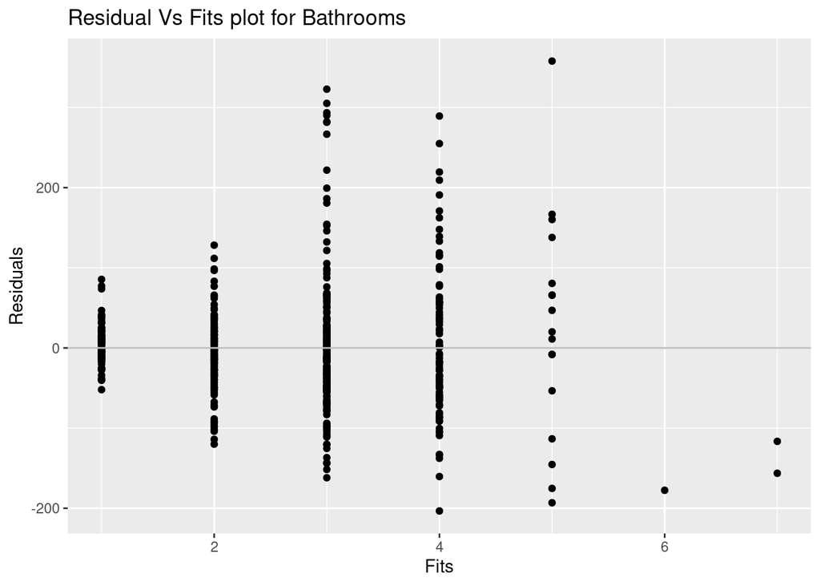

```r
ggplot(df, aes(x = Bathrooms, y=resid)) + geom_point() + ylab("Residuals") + xlab("Fits") + ggtitle("Residual Vs Fits plot for Bathrooms") +  geom_hline(yintercept = 0, color = "grey")
```

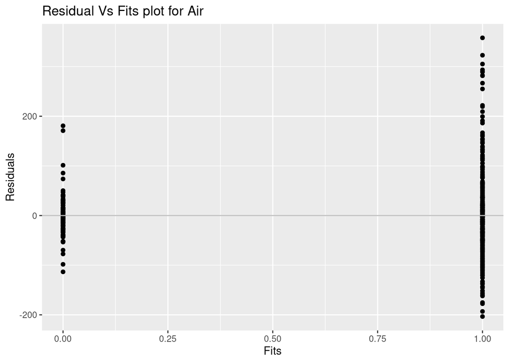

```r
ggplot(df, aes(x = Air, y=resid)) + geom_point() + ylab("Residuals") + xlab("Fits") + ggtitle("Residual Vs Fits plot for Air") +  geom_hline(yintercept = 0, color = "grey")
```

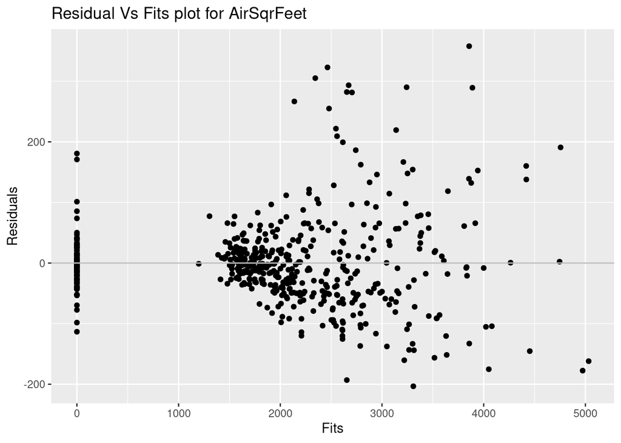

```r
ggplot(df, aes(x = AirSqrFeet, y=resid)) + geom_point() + ylab("Residuals") + xlab("Fits") + ggtitle("Residual Vs Fits plot for AirSqrFeet") +  geom_hline(yintercept = 0, color = "grey")
```

## Partial $R^2$

```r
model_reduced <- lm(SalePrice ~ SqrFeet + Bathrooms + Air + AirSqrFeet, data = df)
model_full <- lm(SalePrice ~ SqrFeet + Bedrooms + Bathrooms + Air + AirSqrFeet, data = df)
```

```r
anova(model_full)
```

```
## Analysis of Variance Table
##
## Response: SalePrice
##             Df  Sum Sq Mean Sq   F value    Pr(>F)
## SqrFeet      1 6666447 6666447 1183.1615 < 2.2e-16 ***
## Bedrooms     1   14478   14478    2.5696 0.1095453
## Bathrooms    1  166243  166243   29.5048 8.614e-08 ***
## Air          1   27206   27206    4.8284 0.0284384 *
## AirSqrFeet   1   71755   71755   12.7350 0.0003924 ***
## Residuals  515 2901734    5634
## ---
## Signif. codes:  0 '***' 0.001 '**' 0.01 '*' 0.05 '.' 0.1 ' ' 1
```

```r
anova(model_reduced)
```

```
## Analysis of Variance Table
##
## Response: SalePrice
##             Df  Sum Sq Mean Sq   F value    Pr(>F)
## SqrFeet      1 6666447 6666447 1165.8406 < 2.2e-16 ***
## Bathrooms    1  128267  128267   22.4316 2.818e-06 ***
## Air          1   22757   22757    3.9798 0.0465752 *
## AirSqrFeet   1   79829   79829   13.9606 0.0002075 ***
## Residuals  516 2950563    5718
## ---
## Signif. codes:  0 '***' 0.001 '**' 0.01 '*' 0.05 '.' 0.1 ' ' 1
```

$$R^2 = \frac{SSE_R - SSE_F}{ SSE_R} = \frac{2950563 - 2901734}{2950563}=
0.016549$$

This would be interpreted as the bedrooms predictor explains 1.65% of the variation in sales price that is not explained by sqrfeet, bathrooms, air, and airsqrfeet.